# Elucidating Drivers and Characteristics of Three Saltwater Intrusion Events

Justine Neville

12/5/2019

## Abstract

Saltwater intrusion is a complex, heterogeneous phenomena threatening coastal freshwaters. It is crucial that we better understand the dynamics of these events, so that we may eventually better characterize them and predict them. In this study, a two year time series dataset was analyzed, observing three periods of major saltwater intrusion events. Wavelet coherence diagrams were used to analyze the salinity depth relationship during two hurricanes. A continuous wavelet transform was used to detect significant periods of variability across the salinity time series during a flash drought in 2019. Results show that significant relationships between salinity and depth can be detected during both hurricanes, but that the relationship isn’t always the same. The continuous wavelet transform reveals a unique pattern in our time series when precipitation is lacking and temperatures are high.

## Introduction

Saltwater intrusion is a phenomena that threatens coastal freshwaters world wide. Having been studied in groundwater for decades, much is known about the physical processes that push saltwater further inland, though this coastal hazard is primarly observed and considered to be a chronic, slowly occurring process. Little attention has been given to saltwater intrusion in surface waters, where saltwater can rapidly be brought far inland via storm surge, wind tides, or drought. Despite this lack of attention, the negative impacts of saltwater intrusion are great and far reaching, ecologically, ranging from loss of agricultural crops, to vegetative stress and mortality, and even to immense carbon and nitrogen loss into coastal waters. However, one little has been done to evaluate how different storm surge and drought events, increase and cause salinity to linger at higher levels than normal.

Another poorly understood facet of saltwater intrusion events is what drives these episodic events. To euclidate what drives individual saltwater intrusion events, one can use wavelet analysis. Given a time series, the continuous wavelet transform can find significant periods of variation across localized time frequency space. To determine if there is a significant common power in time frequency space between two time series variables, as well as the direction of the relationship, one can utilize wavelet coherence diagrams. Finally, wavelet cohereance can be used to inform the user how coherant two time series are in time frequency space. Where the two time series show common power or coherance, we know there is some sort of significant relationship between the two variables, what that relationship is (inverse or direct), how long it persists for within the time series, and where in the time series the relationship originates.

Of the areas experiencing saltwater intrusion, coastal North Carolina, more specifically the Albemarle - Pamlico Peninsula is particularly vulnerable to such events. The majority of the entire region sits just three meters above mean sea level and is currently experiencing saltwater intrusion. Additionally, this region is characterized as one of the poorest regions of North Carolina an is primarly ignored due to it being somewhat sheltered from the ocean by North Carolina’s barrier islands. Nevertheless, this region still faces many of the challenges that come with climate change and sea level rise, but lacks the capital to adapt.

2018 and 2019 brought both large storms and dry summer weather, conditions that are prime for causing saltwater intrusion events. Using a two year timeseries dataset of specific conductance, water level, and precipitation the following questions are answered:

*What was the maximum salinity of the Hurricane Florence and Dorian storm surges and how long did it take for salinity levels to return to average site conditions following each event?* During the flash drought of 2019 what patterns do we see in our salinity data? *Can wavelet coherance diagrams show us both hurricanes and the flash drought in time frequency space?

## Methods

**Data Collection**

Specific conductance, water level, temperature, and other meteorological variables (wind, wind direction, precipitation, relative humidity) at 15-minute intervals from January 1st, 2018 to October 22nd, 2019. For ease of processing, data was aggregated this data to hourly intervals. Three periods of interest were identified for analysis. To analyze storm surge events, a period from September 14 - October 15, 2018 and a period from September 6 - 20, 2019 were extracted to analyze storm surge from hurricanes Florence and Dorian which both impacted the North Carolina coast with flooding and high winds . To evaluate salinity patterns during drought, we extracted a period from September 20 - October 7, 2019 which encompassed the flash drought that eastern North Carolina experienced this year.

| Variable | Units |
| --- | --- |
| Specific Conductance | microS/cm |
| Water Level | m |
| Salinity | ppt |

**Data Tidying and Wrangling**

To tidy the dataset, I first used the lubridate package to ensure all datetimes were in a format readable to R. I then filled any data gaps with values of NA using pad from the padr package. Salinity was then calculated using a known equation and the mutate function. Data were then subsetted from the larger, 4-year record to contain just 2018 and 2019. Further subsets were created later on in the analysis to evaluate only the hurricane and flash drought periods in the dataset. Finally, the last data point was removed from the dataset to ensure an equal timestep throughout the entire dataset.

**Visualizations**

**Statistical Summaries**

Nominal statistics were computed for salinity, specific conductance, water level, and wind speed. These statistics were used to gain information on the extremes data can reach here as well as what average conditions are.

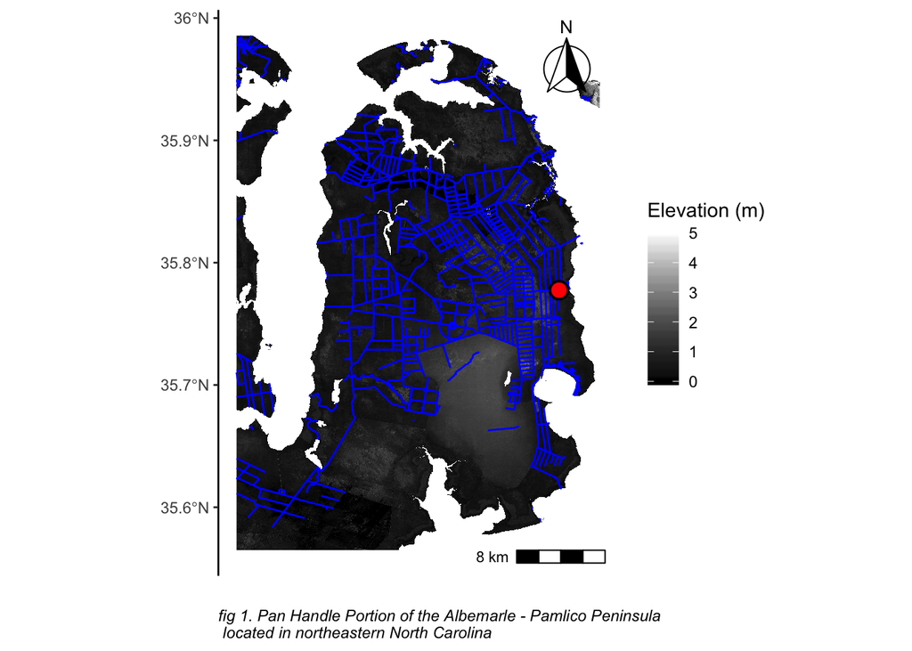

## Results

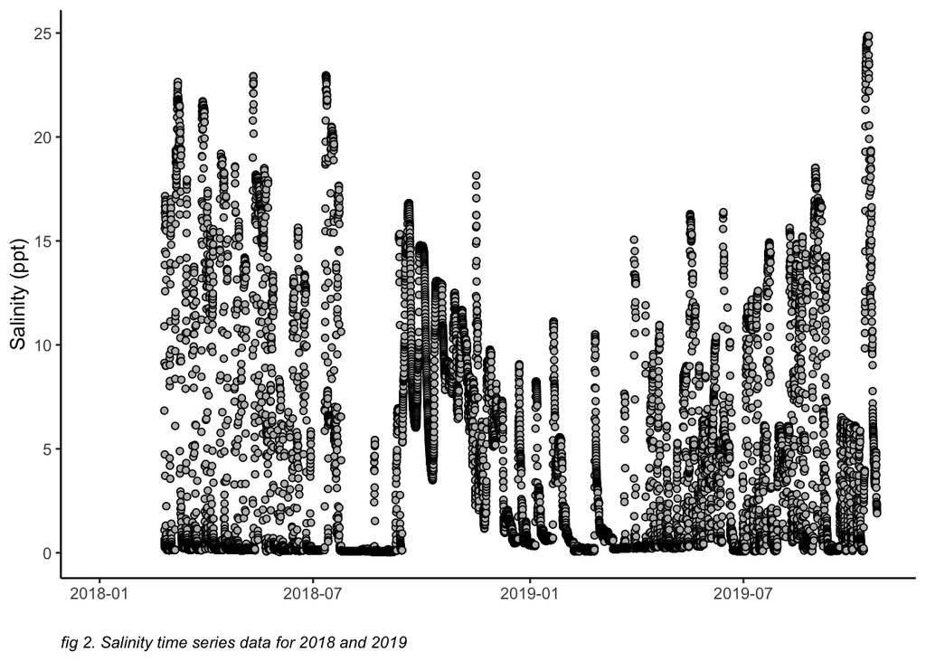

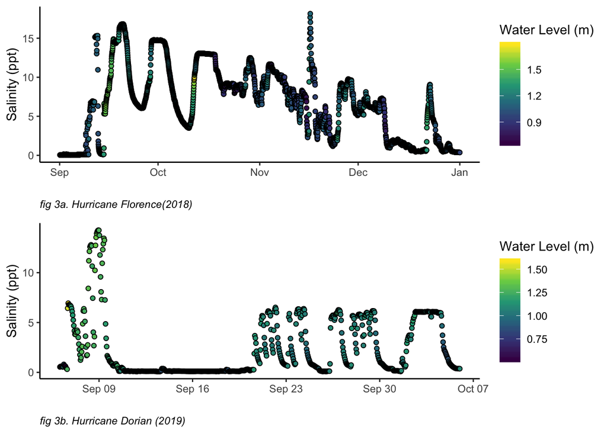

Hurricane Florence Summary Statistics

|  | Date/Time | Water Level (m) | Water Temp (C) | Salinity (ppt) |
| --- | --- | --- | --- | --- |
|  | Min. :2018-09-14 00:45:00 | Min. :0.8128 | Min. :21.92 | Min. : 0.1179 |
|  | 1st Qu.:2018-09-21 18:30:00 | 1st Qu.:1.1201 | 1st Qu.:24.43 | 1st Qu.: 6.3390 |
|  | Median :2018-09-29 12:15:00 | Median :1.1765 | Median :25.51 | Median : 9.6178 |
|  | Mean :2018-09-29 12:15:00 | Mean :1.2149 | Mean :25.35 | Mean : 9.9821 |
|  | 3rd Qu.:2018-10-07 06:00:00 | 3rd Qu.:1.2672 | 3rd Qu.:26.39 | 3rd Qu.:14.5144 |
|  | Max. :2018-10-14 23:45:00 | Max. :1.7847 | Max. :28.41 | Max. :16.8177 |

Hurricane Dorian Summary Statistics

|  | Date/Time | Water Level (m) | Water Temp (C) | Salinity (ppt) |
| --- | --- | --- | --- | --- |
|  | Min. :2019-09-06 01:45:00 | Min. :0.5257 | Min. :20.71 | Min. : 0.07205 |
|  | 1st Qu.:2019-09-09 13:15:00 | 1st Qu.:0.9987 | 1st Qu.:23.57 | 1st Qu.: 0.11029 |
|  | Median :2019-09-13 00:45:00 | Median :1.1042 | Median :24.43 | Median : 0.12168 |
|  | Mean :2019-09-13 00:45:00 | Mean :1.0926 | Mean :24.29 | Mean : 1.69960 |
|  | 3rd Qu.:2019-09-16 12:15:00 | 3rd Qu.:1.1807 | 3rd Qu.:25.19 | 3rd Qu.: 0.80809 |
|  | Max. :2019-09-19 23:45:00 | Max. :1.5879 | Max. :26.63 | Max. :14.26223 |

Wavelet coherence diagrams are a common tool for discovering areas of significant correlations between two time series. Here, a wavelet coherence analysis was run for both hurricanes Florence and Dorian to see if a significant relationship between depth and salinity could be captured during both events. Figures 4a. and 4b. show significant correlations around the time that both hurricanes made landfall. Hurricane Florence made landfall in North Carolina September 14th, 2018. Looking at the wavelet coherence diagram (figure 4a) we see that shortly after Florence made landfall there was a band of significance around the 16 hour period. The arrows at this point in the figure reveal that salinity and depth are in near anti-phase with one another, meaning that as salinity increased, water level decreased. Further evidence of this claim can be seen in figure 3a. Hurricane Dorian too displayed bands of significant correlation between salinity and depth. However, in the hurricane Dorian wavelet coherence diagram, the arrows reveal that the two variables are near in-phase, but that salinity is leading depth by about 45 degrees. This means that as salinity increased, it increased at a slightly faster rate than depth. Evidence of this direct relationship can be seen in the first salinity increase in figure 3b where point colors also show an increase in depth.

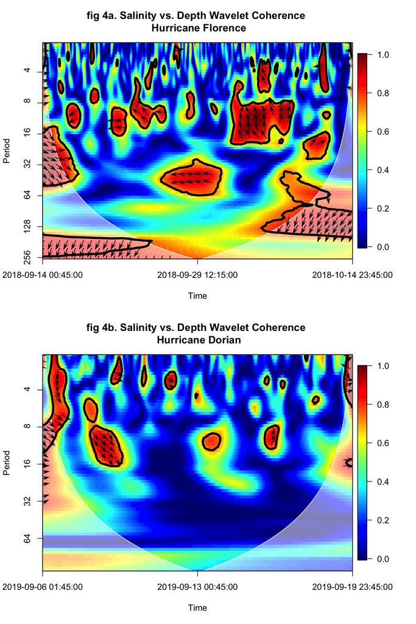

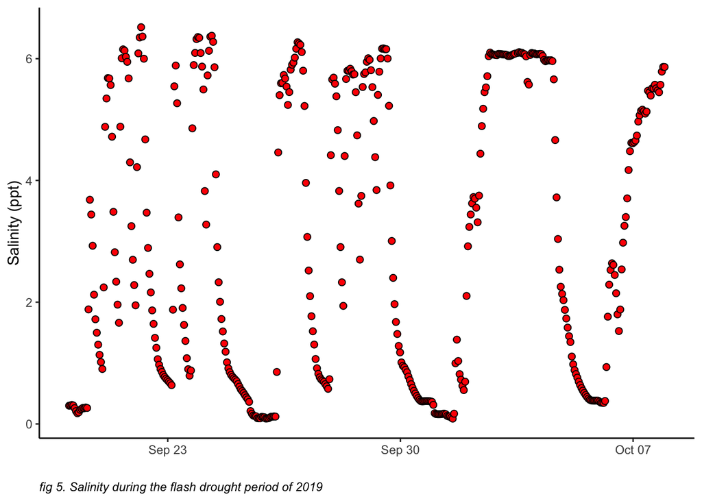

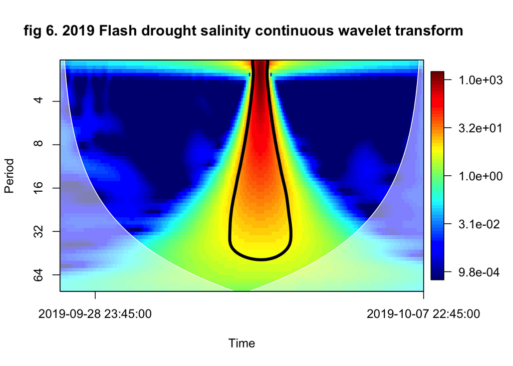